# Exploring Math Wikipedia Page Views

2025-03-12

## Research Question & Motivation

- What is the general publics interaction with Mathematics?
- We will examine this question through analysis of page view statistics for Math-related Wikipedia articles
- Outline:
1. Overview of data set
2. Wikipedia page connection graph
3. Viewership Statistics
4. Relevant events impacting page views

## Math Wikipedia Dataset

- Wikipedia Math Essentials from UCI Machine Learning Repository. (https://archive.ics.uci.edu/dataset/605/wikipedia+math+essentials)
- Daily view count data for 1068 Wikipedia pages related to Mathematics and Statistics, over period of 2 years, with one instance per page per day
- Period in question: March 16, 2019 - March 15, 2021
- Variables: Page Name, Date, View Count, Edges (number of hyperlinks with other pages)

```
##          Page ID Edges       Date Year Month Day Views
## 1 Mathematics  0   533 2019-03-16 2019     3  16  3962
## 2 Mathematics  0   533 2019-03-17 2019     3  17  3923
## 3 Mathematics  0   533 2019-03-18 2019     3  18  4617
## 4 Mathematics  0   533 2019-03-19 2019     3  19  4822
## 5 Mathematics  0   533 2019-03-20 2019     3  20  4871
## 6 Mathematics  0   533 2019-03-21 2019     3  21  4969
```

## Wikipedia Page Connection Map

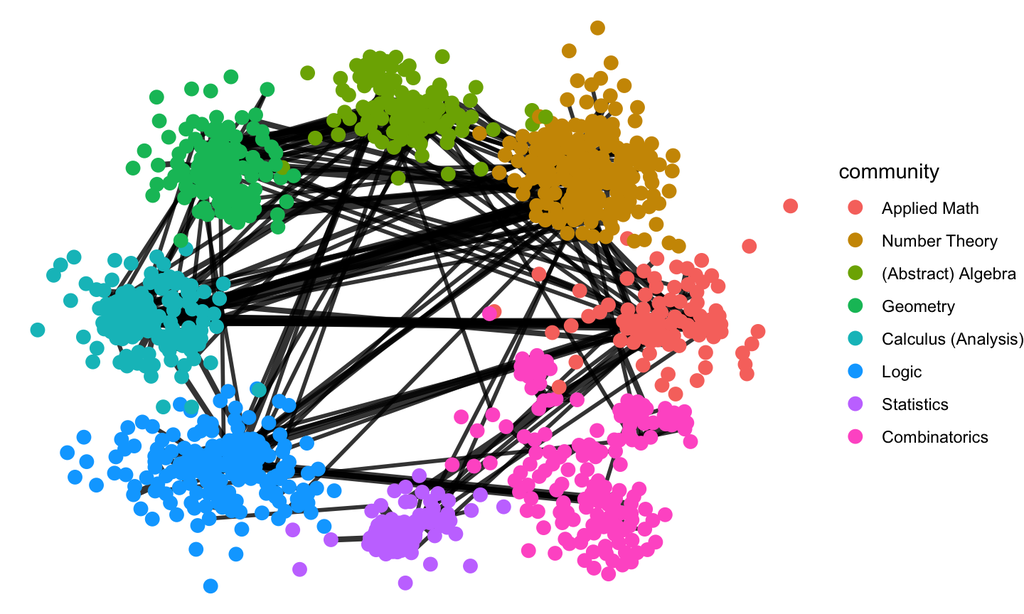

## Top 50 Connected Pages

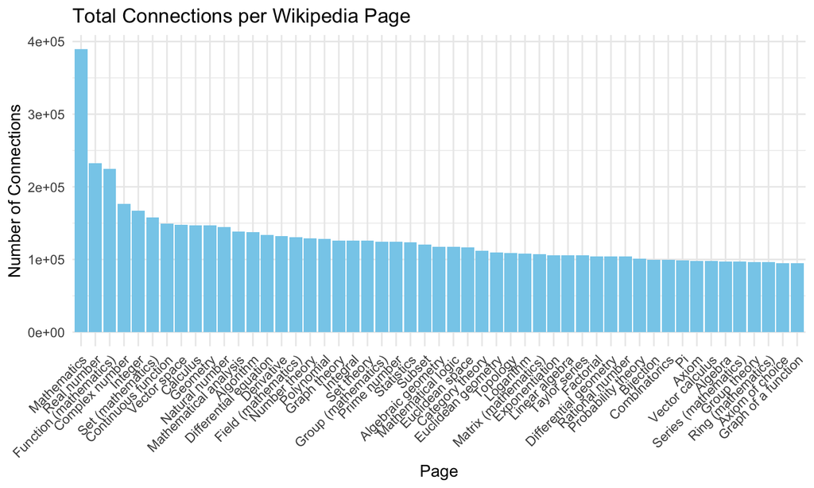

## Most Viewed Pages

```
## # A tibble: 1,068 × 2
##    Page                   Views
##    <chr>                  <int>
##  1 Normal distribution  5355019
##  2 Standard deviation   5131200
##  3 Fibonacci number     4524975
##  4 Pi                   3742122
##  5 Roman numerals       3730168
##  6 Prime number         3368175
##  7 Poisson distribution 3276035
##  8 Mathematics          3192685
##  9 Golden ratio         3038084
## 10 Taylor series        2637277
## # ℹ 1,058 more rows
```

## Average Number of Views per Weekday

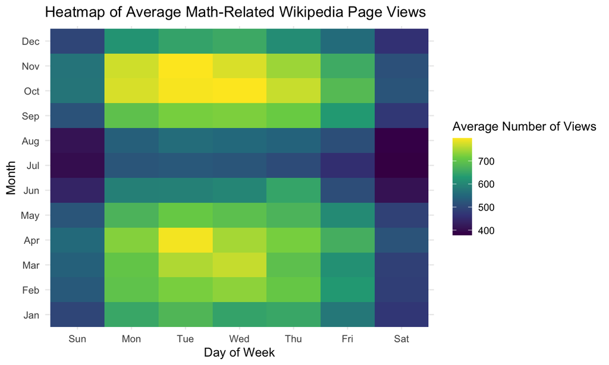

## Math Wikipedia and Media

- Question: What types of events influence public interests in Mathematics, and can we quantify this through Wikipedia page views?
- What do the sources of these sparks in interest tell us about the best way to promote Mathematics to a wider audience?
- Three cases: Math related holidays, mainstream press stories, and Youtube videos

## Shiny App

https://mlewispeinad.shinyapps.io/project1/

- Allows us to filter through different Math Wikipedia pages and date ranges

## Case 1: Math Holidays

- Two notable Math holidays
- Pi Day (March 14)
- Fibonacci Day (November 23)

[figure not shown]

## Case 2: Mainstream Media Articles

- From examining archived articles from publications such as the New York Times, Math related articles are few and far between in the mainstream press.
- Common type of Math-related news article: Obituaries for famous Mathematicians
- Example: John Horton Conway (26 December 1937 – 11 April 2020), known for his contributions to both academic and recreational Mathematics, for example Coding Theory

[figure not shown]

## Exponential Growth

- Early during the COVID pandemic, many people were curious about how the virus was spreading so quickly, leading to talk about the Mathematics behind ‘Exponential Growth’.

[figure not shown]

## Case 3: Youtube

- Youtube has served as a thriving community for exposing Mathematics to a general audience
- Example: 3Blue1Brown (Grant Sanderson), known for producing accessible videos on advanced topics in Math and Science with slick animations
- 7 Million subscribers as of 2025

[figure not shown]

[figure not shown]

## Conclusion

- Given the prevalence of Wikipedia in many of our everyday lives, we can learn a lot about societies relationship with Mathematics through examining trends on Wikipedia
- An important takeaway is that alternative media outlets, such Youtube, are more effective at promoting interest in Mathematics than the traditional press
- Happy early Pi Day!